# BCB420 Assignment 2

Kevin Zhu

## Objective of Assignment 2

The object for this assignment is to take the normalized expression data from the previous Assignment #1 and rank the genes according to differential expression. Once this list ranked, over-representation analysis with thresholds will be performed to highlight the dominant similarities in the top set of genes.

## Installing dependencies and dowloading the packages

These dependencies has are already included with the command in the docker file.

```r
if (!requireNamespace("BiocManager", quietly = TRUE)){
  install.packages("BiocManager")}

if (!requireNamespace("GEOmetadb", quietly = TRUE)){
  BiocManager::install("GEOmetadb")}

if (!requireNamespace("GEOmetadb", quietly = TRUE)){
  install.packages("knitr")}

if (!requireNamespace("edgeR", quietly = TRUE)){
  BiocManager::install("edgeR")}

if (!requireNamespace("biomaRt", quietly = TRUE)){
  BiocManager::install("biomaRt")}

if (!requireNamespace("DBI", quietly = TRUE)){
  install.packages("DBI")}

if (!requireNamespace("GEOquery", quietly = TRUE)){
  BiocManager::install("GEOquery")}

library(GEOquery)
library(knitr)
library(edgeR)
library(biomaRt)
library(dplyr)
library(purrr)
library(ComplexHeatmap)
library(ggplot2)
library(circlize)
library(gprofiler2)
library(magrittr)
```

## Step 1: Differential Gene Expression

The first step for this assignment is to perform differential gene expression analysis.

### Loading the normalized data

We must load in the normalized data that was saved from the previous assignment.

```r
# ensures user does not need to manually run the previous notebook
rmarkdown::render("./A1_KevinZhu.Rmd")
```

```
##
##
## processing file: A1_KevinZhu.Rmd
```

```
## output file: A1_KevinZhu.knit.md
```

```
##
## Output created: A1_KevinZhu.html
```

```r
# read the file containing information about sample types
samples_type <- read.table(file=file.path("./A1/GSE206102_samples_type.txt"),
                                    header = TRUE,sep = "\t",
                                    stringsAsFactors = FALSE,
                                    check.names=FALSE)

# read the file containing normalized and filtered counts
normalized_counts <- read.table(file=file.path(
  "./A1/GSE206102_normalized_filtered_RSEM_counts.txt"
  ),
                                    header = TRUE,sep = "\t",
                                    stringsAsFactors = FALSE,
                                    check.names=FALSE)
dim(normalized_counts)
```

```
## [1] 14244    12
```

### MDS

We can look at the MDS plot below and see that the samples treated with LY411575 and DAPT cluster fairly tightly and closely with each other.

```r
d <- DGEList(counts=as.matrix(normalized_counts),
            group=samples_type$treatment)

# plot multidimensional scaling (MDS) plot
plotMDS(d, labels=NULL, pch = 1,
        col = c("cyan", "red", "darkgreen")[
          factor(samples_type$treatment)])
```

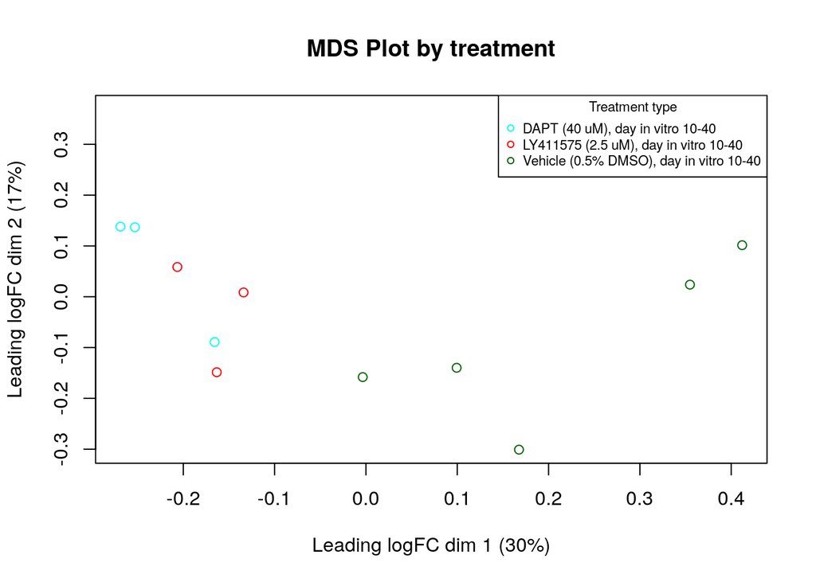

```r
# add legend and title to the plot
title(main = "MDS Plot by treatment")
legend("topright",
       legend = levels(factor(samples_type$treatment)),
       col = c("cyan", "red", "darkgreen"),
       pch = 1,
       cex = 0.7,
       title = "Treatment type")
```

In the experiment, the tissue type, cell line, and cell type were identical for all the samples. Thus, we will look at the replicates to see if it is a factor that needs to be considered.

```r
# create new replicate_number column in samples_type dataframe
samples_type <- samples_type %>%
    mutate(replicate_number =
             as.numeric(gsub("Replicate([0-9]+)_.*", "\\1", title)))

d <- DGEList(counts=as.matrix(normalized_counts),
            group=samples_type$replicate_number)

# plot multidimensional scaling (MDS) plot
plotMDS(d, labels=NULL, pch = 1,
        col = c("cyan", "red", "darkgreen", "black", "violet", "blue")[
          factor(samples_type$replicate_number)])
```

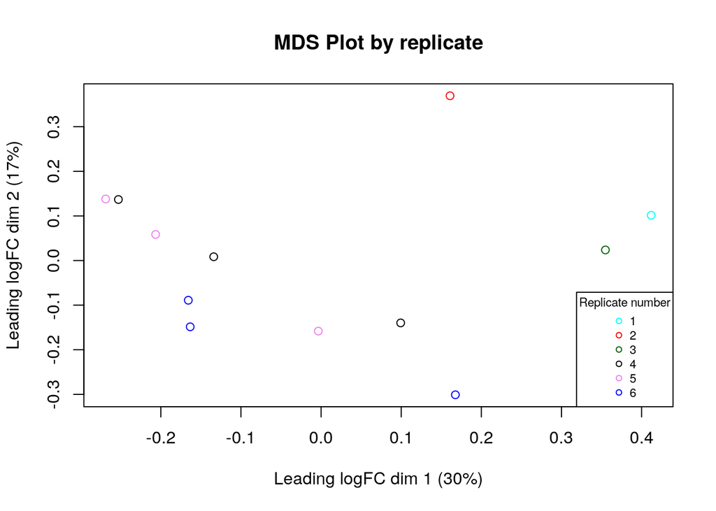

```r
# add legend and title to the plot
title(main = "MDS Plot by replicate")
legend("bottomright",
       legend = levels(factor(samples_type$replicate_number)),
       col = c("cyan", "red", "darkgreen", "black", "violet", "blue"),
       pch = 1,
       cex = 0.7,
       title = "Replicate number")
```

Note that not all of the data for each of the replicates is being used, due to how the data was processed by GEO (explained in more detail in Assignment #1). However, even with the few scattered data points, we can still somewhat observe clustering of replicates 4, 5, and 6.

```r
# create new column to separate control vs gamma_secretase_inhibition
samples_type <- samples_type %>%
  mutate(new_treatment = ifelse(grepl("Vehicle", treatment),
                                "control",
                                "gamma_secretase_inhibition"))
```

### Designing the Model

From the MDS plots, we can define a model based on replicate number and the two treatment groups (control and γ-secretase inhibition). From there, we can fit the model to the data.

```r
d <- DGEList(counts=as.matrix(normalized_counts),
             group=samples_type$new_treatment)

# design  model matrix using both replicate number and new treatment groups
model_design <- model.matrix(~ samples_type$replicate_number +
                               samples_type$new_treatment)

# estimate dispersion
d <- estimateDisp(d, model_design)

# fit quasi-likelihood negative binomial generalized linear model to the data
fit <- glmQLFit(d, model_design)
```

We can then test for significance using this fitted model.

```r
# perform significance test
qlf.ctrl_vs_inhibit <- glmQLFTest(fit, coef=ncol(model_design))

# extract top hits from test
tt_ctrl_vs_inhibit <- topTags(qlf.ctrl_vs_inhibit, n=nrow(d))

# extract results table
top_outputs <- tt_ctrl_vs_inhibit$table
```

Next, we can identify the genes with p-values and FDR values that pass the significance threshold.

```r
# get indices of top outputs with p-value < 0.05
sig_p_idx <- which(top_outputs$PValue < 0.05)

# get indices of top outputs with FDR < 0.1
sig_fdr_idx <- which(top_outputs$FDR < 0.1)
num_p <- length(sig_p_idx)
num_fdr <- length(sig_fdr_idx)
```

In this analysis, we have chosen the typical significance threshold α=0.05; we can see that 437 genes exhibited statistically significant differential expression (their p-values < 0.05).

Applying the standard significance threshold, this time considering the FDR, our analysis identifies 91 genes exhibiting significant differential expression.

### Volcano Plot

To concisely visualize our analysis, we can us a volcano plot, as shown below. Within this plot, we emphasize genes of significance—those exhibiting an FDR < 0.1 and an absolute log2 fold change exceeding 0.25. The classification of these genes as upregulated or downregulated is determined by the sign of their respective log2 fold changes.

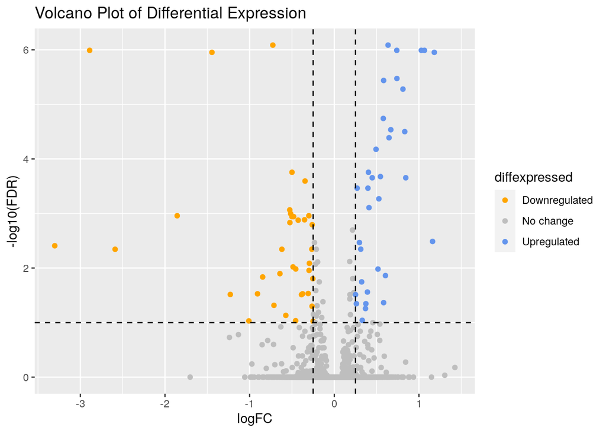

```r
# label top hits with differential expression status
top_outputs$diffexpressed <-
  ifelse(top_outputs$logFC > 0.25 & top_outputs$FDR < 0.1,
         "Upregulated",
         ifelse(top_outputs$logFC < -0.25 & top_outputs$FDR < 0.1,
                "Downregulated",
                "No change"))

write.table(top_outputs,
            file = file.path(getwd(), "A2", "top_outputs.txt"),
            sep = "\t", row.names = TRUE)


# define colors based on differential expression status
cols <- ifelse(top_outputs$logFC > 0.25 & top_outputs$FDR < 0.1,
               "cornflowerblue",
               ifelse(top_outputs$logFC < -0.25 & top_outputs$FDR < 0.1,
                      "orange",
                      "grey"))

# create scatter plot
ggplot(data = top_outputs,
       aes(x = logFC, y = -log10(FDR), col = diffexpressed)) +
  geom_point() +
  scale_color_manual(values = c("orange", "grey", "cornflowerblue")) +
  geom_hline(yintercept = -log10(0.1), col = "black", lty = 2) +
  geom_vline(xintercept = c(-0.25, 0.25), col = "black", lty = 2) +
  ggtitle("Volcano Plot of Differential Expression")
```

### Heatmap

We can now generate a heatmap to illustrate the scaled differences in normalized RNA counts among the top hits.

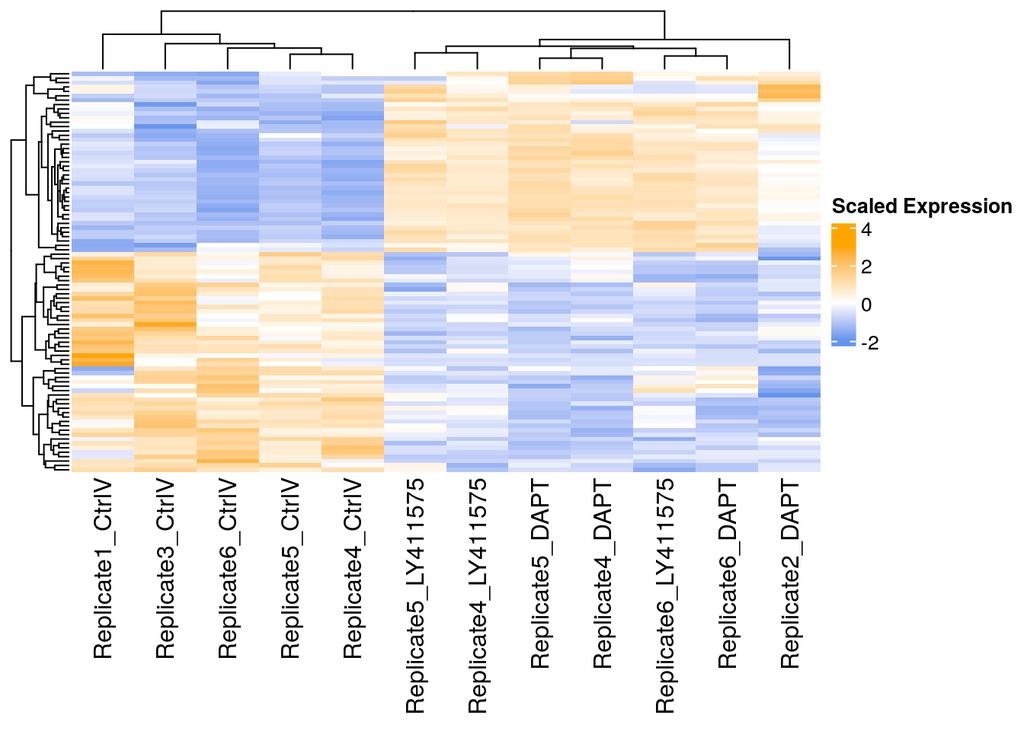

```r
# get names of significant genes
sig_genes <- rownames(top_outputs)[sig_fdr_idx]

# get indices of significant genes in counts data
sig_baseline_idx <- which(rownames(normalized_counts) %in% sig_genes)

# scale the data
scaled_hits_heatmap_matrix <- t(
  scale(t(as.matrix(normalized_counts[sig_baseline_idx,]))))

# create the colorscales based on if there are negative scaled count values
if(min(scaled_hits_heatmap_matrix) < 0){
  colscale <- colorRamp2(c(min(scaled_hits_heatmap_matrix),
                           0, max(scaled_hits_heatmap_matrix)),
                           c("cornflowerblue", "white", "orange"))
} else {
  colscale <- colorRamp2(c(min(scaled_hits_heatmap_matrix),
                           max(scaled_hits_heatmap_matrix)),
                           c("white", "orange"))
}



# create heatmap
Heatmap(scaled_hits_heatmap_matrix,
        cluster_rows = TRUE,
        cluster_columns = TRUE,
        show_row_dend=TRUE,
        col = colscale,
        show_column_names = TRUE,
        show_row_names = FALSE,
        show_heatmap_legend=TRUE,
        name = "Scaled Expression"
        )
```

We can see in the heatmap above that the samples treated with DAPT and LY411575 all seem to cluster together, separate from the control samples. As mentioned earlier, this behavior was expected as both treatments were intended to pharmaceutically induce chronic γ-secretase inhibition; their transcriptomes would be relatively similar. Notably, there is a distinct difference in the expression of the top hits between the control and treated conditions, which somewhat affirms our methodology.

## Thresholded overrepresentation analysis

As shown below, we conducted a threshold gene set enrichment analysis on the top hits, using for `g:Profiler` as the tool of choice. This decision was driven by pre-existing familiarity with the interface. Furthermore, the use of g:Profiler enables us to deduce enriched biological pathways and functional annotations associated with top hits, enhancing the interpretation of our analysis.

The thresholded lists were generated based on an FDR < 0.01 and whether the log fold change is greater than or less than zero, along with the entire list.

```r
# get indices of significant upregulated and downregulated
up_idx <- which(tt_ctrl_vs_inhibit$table$FDR < 0.01 &
                  tt_ctrl_vs_inhibit$table$logFC > 0)
down_idx <- which(tt_ctrl_vs_inhibit$table$FDR < 0.01 &
                    tt_ctrl_vs_inhibit$table$logFC < 0)

# get gene names of upregulated genes
upreg <- tt_ctrl_vs_inhibit$table[up_idx,]
upreg_list <- rownames(upreg)

# get gene names of downregulated genes
downreg <- tt_ctrl_vs_inhibit$table[down_idx,]
downreg_list <- rownames(downreg)
```

Using `g:Profiler` on the upregulated and downregulated lists, we can perform a thresholded over-representation analysis to identify a number of pathways and genesets for each query.

```r
# query gprofiler for upregulated list
gostres_up <- gost(query = upreg_list,
                organism = "hsapiens", significant = FALSE, exclude_iea = TRUE,
                correction_method = "fdr",
                domain_scope = "annotated",
                numeric_ns = "", sources = c("GO:BP", "REAC", "WP"))

# query gprofiler for downregulated list
gostres_down <- gost(query = downreg_list,
                organism = "hsapiens", significant = FALSE, exclude_iea = TRUE,
                correction_method = "fdr",
                domain_scope = "annotated",
                numeric_ns = "", sources = c("GO:BP", "REAC", "WP"))

# query gprofiler for whole list
gostres <-  gost(query = c(upreg_list, downreg_list),
                organism = "hsapiens", significant = FALSE, exclude_iea = TRUE,
                correction_method = "fdr",
                domain_scope = "annotated",
                numeric_ns = "", sources = c("GO:BP", "REAC", "WP"))

num_genesets_up <- nrow(gostres_up$result)
num_genesets_down <- nrow(gostres_down$result)
num_genesets_all <- nrow(gostres$result)
```

Next, we can filter out terms that are too large, as they may obscure relevant pathways. Instead, we take only genesets with a term size that is less than or equal to 200 (similar thresholds in the `g:Profiler` homework assignment).

```r
# filter for terms with term_size <= 200
filtered_gos_up <- gostres_up$result[which(gostres_up$result$term_size <= 200),]
filtered_gos_down <- gostres_down$result[which(gostres_down$result$term_size <= 200),]
filtered_gos <- gostres$result[which(gostres$result$term_size <= 200),]
```

This analysis incorporates GO biological process, Reactome, and WikiPathways as annotation databases. This selections aligns with our goal on uncovering enriched biological pathways associated with the identified genes. Note that electronic GO annotations were exluded to ensure that only high-quality annotations were being used in our analysis.

```r
# select first 12 rows and columns ("term_name" and "p_value") from data frame
filtered_gos_up[1:12,c("term_name", "p_value")] %>%
  kable(caption="Table 1. Top filtered pathways hits for upregulated genes.",
      row.names = FALSE, digits = 32)
```

Table 1. Top filtered pathways hits for upregulated genes.

| term_name | p_value |
| --- | --- |
| sterol biosynthetic process | 1.490270e-27 |
| cholesterol biosynthetic process | 7.166263e-26 |
| secondary alcohol biosynthetic process | 7.166263e-26 |
| secondary alcohol metabolic process | 2.939814e-25 |
| cholesterol metabolic process | 1.475541e-23 |
| sterol metabolic process | 8.510294e-23 |
| steroid biosynthetic process | 2.189566e-21 |
| alcohol biosynthetic process | 1.653206e-20 |
| organic hydroxy compound biosynthetic process | 2.030676e-19 |
| isoprenoid biosynthetic process | 7.936236e-09 |
| isoprenoid metabolic process | 6.557744e-07 |
| farnesyl diphosphate metabolic process | 1.485587e-06 |

```r
# select first 12 rows and columns ("term_name" and "p_value") from data frame
filtered_gos_down[1:12,c("term_name", "p_value")] %>%
  kable(caption="Table 2. Top filtered pathways hits for downregulated genes.",
      row.names = FALSE, digits = 52)
```

Table 2. Top filtered pathways hits for downregulated genes.

| term_name | p_value |
| --- | --- |
| purine nucleoside diphosphate catabolic process | 1.552260e-09 |
| ADP metabolic process | 1.552260e-09 |
| ADP catabolic process | 1.552260e-09 |
| purine ribonucleoside diphosphate catabolic process | 1.552260e-09 |
| purine ribonucleoside diphosphate metabolic process | 1.552260e-09 |
| ribonucleoside diphosphate catabolic process | 1.552260e-09 |
| pyridine nucleotide catabolic process | 1.552260e-09 |
| glycolytic process | 1.552260e-09 |
| purine nucleoside diphosphate metabolic process | 1.552260e-09 |
| pyridine-containing compound catabolic process | 1.680878e-09 |
| nucleoside diphosphate catabolic process | 1.998545e-09 |
| ribonucleoside diphosphate metabolic process | 2.371920e-09 |

```r
# select first 12 rows and columns ("term_name" and "p_value") from data frame
filtered_gos[1:12, c("term_name", "p_value")] %>%
  kable(caption="Table 3. Top filtered pathways hits for differentially expressed genes.",
      row.names = FALSE, digits = 32)
```

Table 3. Top filtered pathways hits for differentially expressed genes.

| term_name | p_value |
| --- | --- |
| sterol biosynthetic process | 6.853780e-27 |
| secondary alcohol biosynthetic process | 1.099583e-25 |
| cholesterol biosynthetic process | 1.099583e-25 |
| secondary alcohol metabolic process | 2.416039e-23 |
| cholesterol metabolic process | 3.822133e-22 |
| steroid biosynthetic process | 2.430720e-21 |
| sterol metabolic process | 2.515374e-21 |
| alcohol biosynthetic process | 2.801910e-19 |
| organic hydroxy compound biosynthetic process | 2.074894e-17 |
| glycolytic process | 1.102786e-07 |
| ADP catabolic process | 1.102786e-07 |
| purine ribonucleoside diphosphate catabolic process | 1.162253e-07 |

## Interpretation

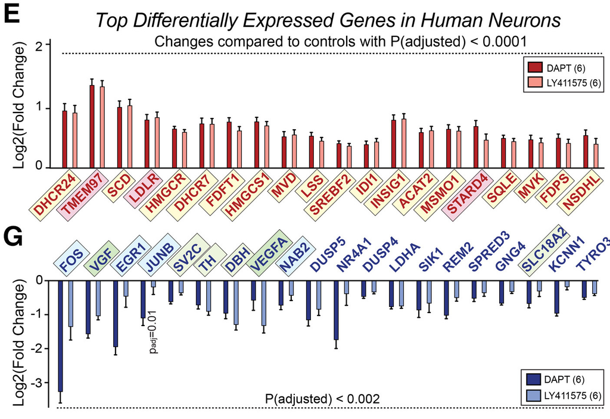

Furthermore, the down-regulated genes were also described as being relatively heterogeneous in terms of function and pathway (Figure 4G), suggesting a less direct correlation with γ-secretase levels. This is also corroborated by the g:Profiler analysis.

Other sources of literature seems to support the conclusions in the paper. In “Inhibition of Cholesterol Biosynthesis Reduces γ-Secretase Activity and Amyloid-β Generation,” (Kim et al., 2016), a relationship between γ-secretase and cholesterol biosynthesis is similarly identified, although in the inverse direction. More specifically, the authors of the paper depleted cholesterol using AY49944, which blocks the final step of cholesterol biosynthesis. The application of this diamine demonstrated a notable reduction in γ-secretase activity, further reinforcing the observed link between cholesterol metabolism and γ-secretase function.

## References

Bache S, Wickham H (2022). *magrittr: A Forward-Pipe Operator for R*. R package version 2.0.3, https://github.com/tidyverse/magrittr, https://magrittr.tidyverse.org.

Davis, S. and Meltzer, P. S. GEOquery: a bridge between the Gene Expression Omnibus (GEO) and BioConductor. Bioinformatics, 2007, 14, 1846-1847

Essayan-Perez, Sofia, and Thomas C Südhof. “Neuronal γ-Secretase Regulates Lipid Metabolism, Linking Cholesterol to Synaptic Dysfunction in Alzheimer’s Disease.” Neuron, vol. 111, no. 20, 1 Oct. 2023, pp. 3176-3194.e7, https://doi.org/10.1016/j.neuron.2023.07.005.

Gu Z, Eils R, Schlesner M (2016). “Complex heatmaps reveal patterns and correlations in multidimensional genomic data.” Bioinformatics. doi:10.1093/bioinformatics/btw313.

Gu Z (2022). “Complex Heatmap Visualization.” iMeta. doi:10.1002/imt2.43.

Gu Z, Gu L, Eils R, Schlesner M, Brors B (2014). “circlize implements and enhances circular visualization in R.” Bioinformatics, 30, 2811-2812.

Kim, Y., Kim, C., Jang, H. Y., & Mook-Jung, I. (2016). Inhibition of cholesterol biosynthesis reduces γ-secretase activity and amyloid-β generation. Journal of Alzheimer’s Disease, 51(4), 1057–1068. https://doi.org/10.3233/jad-150982

Kolberg L, Raudvere U, Kuzmin I, Vilo J, Peterson H (2020). “gprofiler2– an R package for gene list functional enrichment analysis and namespace conversion toolset g:Profiler.” F1000Research, 9 (ELIXIR)(709). R package version 0.2.3.

Martin, Fergal J., et al. “Ensembl 2023.” Nucleic Acids Research, vol. 51, no. D1, 6 Jan. 2023, pp. D933–D941, pubmed.ncbi.nlm.nih.gov/36318249/, https://doi.org/10.1093/nar/gkac958.

Robinson MD, McCarthy DJ and Smyth GK (2010). edgeR: a Bioconductor package for differential expression analysis of digital gene expression data. Bioinformatics 26, 139-140

Wickham H (2016). ggplot2: Elegant Graphics for Data Analysis. Springer-Verlag New York. ISBN 978-3-319-24277-4, https://ggplot2.tidyverse.org.

Wickham H, Henry L (2023). *purrr: Functional Programming Tools*. R package version 1.0.2, https://github.com/tidyverse/purrr, https://purrr.tidyverse.org/.

Wickham H, François R, Henry L, Müller K, Vaughan D (2023). *dplyr: A Grammar of Data Manipulation*. R package version 1.1.4, https://CRAN.R-project.org/package=dplyr.

Yihui Xie (2015) Dynamic Documents with R and knitr. 2nd edition. Chapman and Hall/CRC. ISBN 978-1498716963

Mapping identifiers for the integration of genomic datasets with the R/Bioconductor package biomaRt. Steffen Durinck, Paul T. Spellman, Ewan Birney and Wolfgang Huber, Nature Protocols 4, 1184-1191 (2009).